# Regression Learning Manuscript

Julie M. Schneider

2021-03-31

## Import and merge data

### Create column for Age

```r
df$age_year<- ifelse(df$age_months < 108, 8, ifelse(df$age_months >= 108 & df$age_months < 120, 9, ifelse(df$age_months >= 120 & df$age_months < 132, 10, ifelse(df$age_months >= 132 & df$age_months < 144, 11, ifelse(df$age_months >= 144 & df$age_months < 156, 12, ifelse(df$age_months >= 156 & df$age_months < 168,13, ifelse(df$age_months >= 168 & df$age_months < 180, 14,ifelse(df$age_months >= 180 & df$age_months < 192, 15,ifelse(df$age_months > 192, 16,99)))))))))
```

### Use most complete dataset

```r
df$subject<-as.factor(as.character(df$subject))
df<- df[-c(2,45,58,62,63,73,76,85,86,88,105,140,207,223,237,238,256,261,262,266,268,275),]
```

## Evaluate the existing dataset & remove outliers

```r
df$GORT_ORI<-as.numeric(as.character(df$GORT_ORI))
df$rate<-as.numeric(as.character(df$rate))
df$acc<-as.numeric(as.character(df$acc))
df$fluency<-as.numeric(as.character(df$fluency))
df$comp<-as.numeric(as.character(df$comp))
df$PPVT_SS<-as.numeric(as.character(df$PPVT_SS))
df$Mat_ed<-as.numeric(as.character(df$Mat_ed))
df$NWR.PCC<-as.numeric(as.character(df$NWR.PCC))
df$twre_pde<-as.numeric(as.character(df$twre_pde))
df$digit<-as.numeric(as.character(df$digit))
df$lang_exp<-as.numeric(as.character(df$lang_exp))
df$subject<-as.numeric(as.character(df$subject))
df$WL_PC<-as.numeric(as.character(df$WL_PC))

range(df$WL_PC)
```

```
## [1] 0.00 0.98
```

```r
df <- df[!(df$WL_PC < .08), ]

#df<- mutate_all(df, function(x) as.numeric(as.character(x)))
#colMeans(df)
```

## RQ: Do SES related gaps in word learning change across ages 8-15?

### Answer: No, there are significant SES related gaps in WL (model 2) but these do not significantly change on the basis of age (model 3; cross-sectional data)

```r
onePredictorModel <- lm(WL_PC ~ age_months + lang_exp, df)
twoPredictorModel <- lm(WL_PC ~ age_months + lang_exp + Mat_ed, df)
threePredictorModel <- lm(WL_PC ~ lang_exp +age_months*Mat_ed, df)

summary(onePredictorModel)
```

```
##
## Call:
## lm(formula = WL_PC ~ age_months + lang_exp, data = df)
##
## Residuals:
##      Min       1Q   Median       3Q      Max
## -0.53584 -0.09633  0.01453  0.12627  0.33381
##
## Coefficients:
##               Estimate Std. Error t value Pr(>|t|)
## (Intercept)  0.1208041  0.0598861   2.017 0.044762 *
## age_months   0.0039724  0.0004298   9.242  < 2e-16 ***
## lang_exp    -0.0790069  0.0207966  -3.799 0.000183 ***
## ---
## Signif. codes:  0 '***' 0.001 '**' 0.01 '*' 0.05 '.' 0.1 ' ' 1
##
## Residual standard error: 0.1772 on 245 degrees of freedom
## Multiple R-squared:  0.2744, Adjusted R-squared:  0.2685
## F-statistic: 46.34 on 2 and 245 DF,  p-value: < 2.2e-16
```

```r
effectsize(onePredictorModel)
```

| Parameter | Std_Coefficient | CI | CI_low | CI_high |
| --- | --- | --- | --- | --- |
| (Intercept) | -5.176881e-18 | 0.95 | -0.1069729 | 0.1069729 |
| age_months | 5.067003e-01 | 0.95 | 0.3987085 | 0.6146920 |
| lang_exp | -2.082882e-01 | 0.95 | -0.3162799 | -0.1002965 |

```r
summary(twoPredictorModel)
```

```
##
## Call:
## lm(formula = WL_PC ~ age_months + lang_exp + Mat_ed, data = df)
##
## Residuals:
##      Min       1Q   Median       3Q      Max
## -0.56379 -0.09962  0.02163  0.12384  0.32088
##
## Coefficients:
##               Estimate Std. Error t value Pr(>|t|)
## (Intercept)  1.271e-05  6.249e-02   0.000    1.000
## age_months   3.965e-03  4.113e-04   9.639  < 2e-16 ***
## lang_exp    -3.376e-02  2.198e-02  -1.536    0.126
## Mat_ed       4.259e-02  8.784e-03   4.849 2.21e-06 ***
## ---
## Signif. codes:  0 '***' 0.001 '**' 0.01 '*' 0.05 '.' 0.1 ' ' 1
##
## Residual standard error: 0.1696 on 244 degrees of freedom
## Multiple R-squared:  0.3382, Adjusted R-squared:  0.3301
## F-statistic: 41.57 on 3 and 244 DF,  p-value: < 2.2e-16
```

```r
effectsize(twoPredictorModel)
```

| Parameter | Std_Coefficient | CI | CI_low | CI_high |
| --- | --- | --- | --- | --- |
| (Intercept) | -2.597951e-17 | 0.95 | -0.1023752 | 0.10237515 |
| age_months | 5.057686e-01 | 0.95 | 0.4024178 | 0.60911952 |
| lang_exp | -8.899106e-02 | 0.95 | -0.2031392 | 0.02515709 |
| Mat_ed | 2.792384e-01 | 0.95 | 0.1658042 | 0.39267264 |

```r
summary(threePredictorModel)
```

```
##
## Call:
## lm(formula = WL_PC ~ lang_exp + age_months * Mat_ed, data = df)
##
## Residuals:
##      Min       1Q   Median       3Q      Max
## -0.56311 -0.09910  0.02159  0.12379  0.32088
##
## Coefficients:
##                     Estimate Std. Error t value Pr(>|t|)
## (Intercept)       -8.344e-03  1.156e-01  -0.072    0.942
## lang_exp          -3.370e-02  2.204e-02  -1.529    0.128
## age_months         4.025e-03  8.083e-04   4.979 1.21e-06 ***
## Mat_ed             4.612e-02  4.194e-02   1.100    0.273
## age_months:Mat_ed -2.548e-05  2.961e-04  -0.086    0.932
## ---
## Signif. codes:  0 '***' 0.001 '**' 0.01 '*' 0.05 '.' 0.1 ' ' 1
##
## Residual standard error: 0.1699 on 243 degrees of freedom
## Multiple R-squared:  0.3382, Adjusted R-squared:  0.3273
## F-statistic: 31.05 on 4 and 243 DF,  p-value: < 2.2e-16
```

```r
effectsize(threePredictorModel)
```

| Parameter | Std_Coefficient | CI | CI_low | CI_high |
| --- | --- | --- | --- | --- |
| (Intercept) | -0.000213895 | 0.95 | -0.1029168 | 0.10248902 |
| lang_exp | -0.088838408 | 0.95 | -0.2032752 | 0.02559835 |
| age_months | 0.505706973 | 0.95 | 0.4021335 | 0.60928046 |
| Mat_ed | 0.279360977 | 0.95 | 0.1656584 | 0.39306358 |
| age_months:Mat_ed | -0.004414404 | 0.95 | -0.1054685 | 0.09663968 |

```r
anova(onePredictorModel,twoPredictorModel,threePredictorModel)
```

|  | Res.Df | RSS | Df | Sum of Sq | F | Pr(>F) |
| --- | --- | --- | --- | --- | --- | --- |
| 1 | 245 | 7.690990 | NA | NA | NA | NA |
| 2 | 244 | 7.015035 | 1 | 0.675954328 | 23.415691511 | 2.320526e-06 |
| 3 | 243 | 7.014822 | 1 | 0.000213737 | 0.007404051 | 9.315001e-01 |

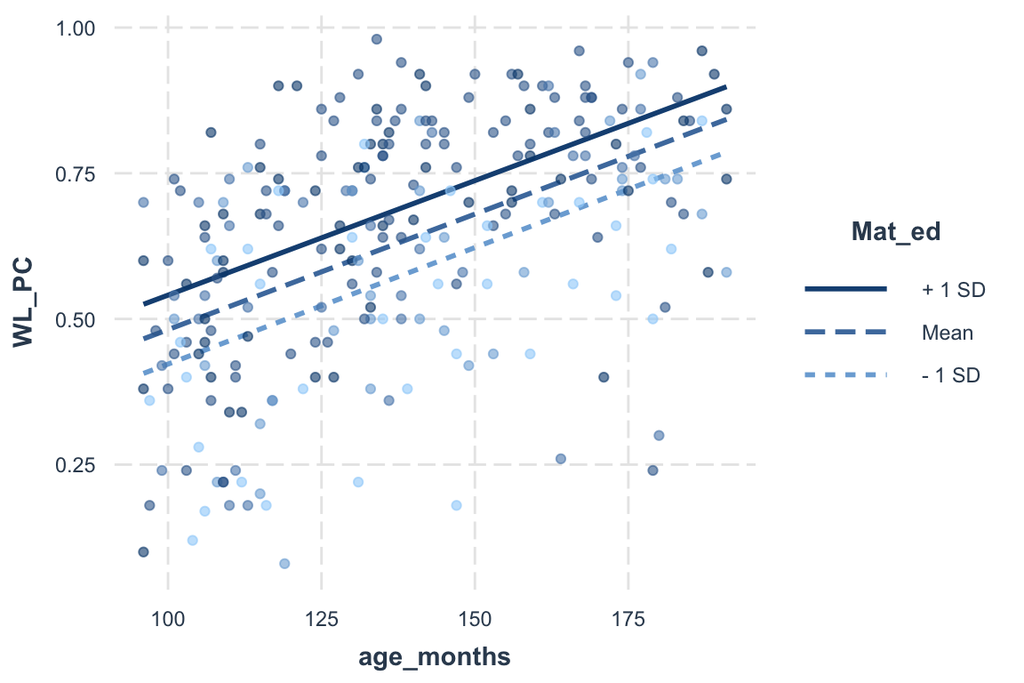

```r
#pdf("Figs/mated_regression.pdf")
interact_plot(threePredictorModel, pred = age_months, modx = Mat_ed, plot.points = TRUE)
```

```r
#dev.off()
```

## RQ: What variables are strongly associated with word learning ability?

### Correlation between Languag and Environmental Measures

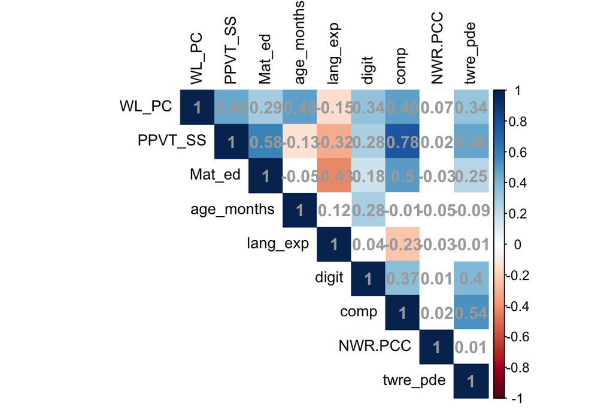

```r
myvars <- c("WL_PC","PPVT_SS","Mat_ed","age_months","lang_exp","digit","comp", "NWR.PCC","twre_pde")
df_subset <- df[myvars]

#Overall Correlation
overall_corr<-rcorr(as.matrix(df_subset))
corrplot(overall_corr$r, method = "color", type = "upper",addCoef.col="dark grey", tl.col = "black", p.mat = overall_corr$P, sig.level = 0.05, insig = "blank", tl.cex = 0.9)
```

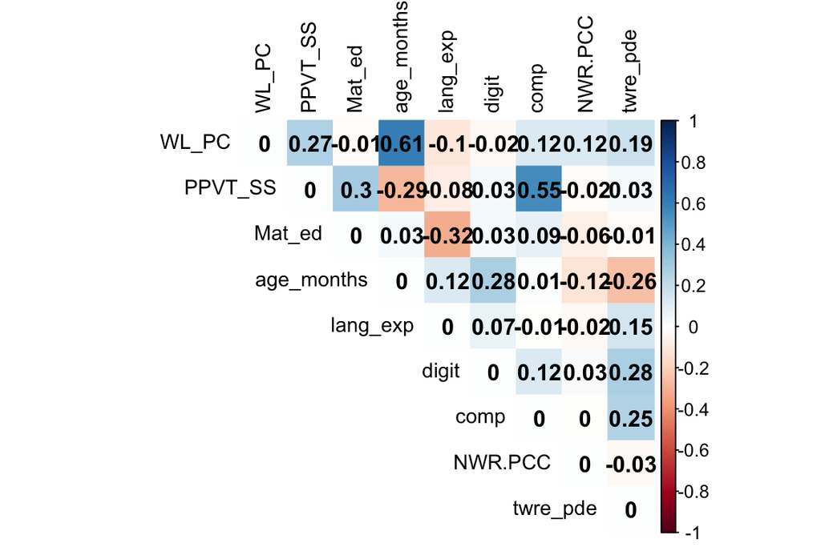

```r
#Partial Correlation, where each bivariate comparison controls for all other variables in matrix
par_overall_corr <- partial.cor(df_subset, tests=TRUE, use=c("pairwise.complete.obs"))
#pdf(file = "partial_corr_behavior_adjusted.pdf")
corrplot(par_overall_corr$R, method = "color", type = "upper",addCoef.col="black", tl.col = "black", p.mat = par_overall_corr$P.unadj, sig.level = 0.05, insig = "blank", tl.cex = 0.9)
```

```r
#dev.off()

#Correlation between specific variables, while controlling for a specific variable
source("pcor.R")
pcor.test(df$PPVT_SS, df$age_months, df$Mat_ed, use = c("mat"), method = c("pearson"), na.rm = T)
```

| estimate | p.value | statistic | n | gn | Method | Use |
| --- | --- | --- | --- | --- | --- | --- |
| -0.1245746 | 0.04938994 | -1.96521 | 248 | 1 | Pearson | Var-Cov matrix |

```r
pcor.test(df$PPVT_SS, y = df$age_months,
          z = df[, c("Mat_ed", "lang_exp", "comp")])
```

| estimate | p.value | statistic | n | gn | Method | Use |
| --- | --- | --- | --- | --- | --- | --- |
| -0.1774246 | 0.00494856 | -2.810363 | 248 | 3 | Pearson | Var-Cov matrix |

## RQ: Which abilities are most strongly related with an individual’s word learning? SES, age, vocabulary, language exposure, reading comprehension, working memory, and phonological working memory

### Answer: Age, vocabulary, and reading comprehension are all strongly positively associated. Phonological working memory is 0.06 (will not investigate further).

```r
myvars <- c("WL_PC","PPVT_SS","Mat_ed","age_months","lang_exp","digit","comp", "NWR.PCC")
df_step <- df[myvars]
df_step<-na.omit(df_step)

library(MASS)
library(car)
library(lm.beta)
# Fit the full model
full.model <-lm(WL_PC ~ lang_exp + digit + NWR.PCC + comp+ Mat_ed + PPVT_SS + age_months, df_step)

summary(full.model)
```

```
##
## Call:
## lm(formula = WL_PC ~ lang_exp + digit + NWR.PCC + comp + Mat_ed +
##     PPVT_SS + age_months, data = df_step)
##
## Residuals:
##      Min       1Q   Median       3Q      Max
## -0.58008 -0.09015  0.01078  0.09157  0.35217
##
## Coefficients:
##               Estimate Std. Error t value Pr(>|t|)
## (Intercept) -0.5297279  0.0910674  -5.817 1.91e-08 ***
## lang_exp    -0.0200556  0.0188747  -1.063  0.28905
## digit        0.0020426  0.0039318   0.520  0.60388
## NWR.PCC      0.0017344  0.0009139   1.898  0.05891 .
## comp         0.0129995  0.0045621   2.849  0.00476 **
## Mat_ed      -0.0017412  0.0087765  -0.198  0.84290
## PPVT_SS      0.0041195  0.0009045   4.554 8.38e-06 ***
## age_months   0.0041323  0.0003724  11.095  < 2e-16 ***
## ---
## Signif. codes:  0 '***' 0.001 '**' 0.01 '*' 0.05 '.' 0.1 ' ' 1
##
## Residual standard error: 0.1433 on 239 degrees of freedom
## Multiple R-squared:  0.5344, Adjusted R-squared:  0.5208
## F-statistic: 39.19 on 7 and 239 DF,  p-value: < 2.2e-16
```

```r
lm.beta(full.model)
```

```
##
## Call:
## lm(formula = WL_PC ~ lang_exp + digit + NWR.PCC + comp + Mat_ed +
##     PPVT_SS + age_months, data = df_step)
##
## Standardized Coefficients::
## (Intercept)    lang_exp       digit     NWR.PCC        comp      Mat_ed
##  0.00000000 -0.05292686  0.02611489  0.08409430  0.20709078 -0.01144227
##     PPVT_SS  age_months
##  0.34911940  0.52602374
```

```r
effectsize(full.model)
```

| Parameter | Std_Coefficient | CI | CI_low | CI_high |
| --- | --- | --- | --- | --- |
| (Intercept) | 3.432566e-16 | 0.95 | -0.086768910 | 0.08676891 |
| lang_exp | -5.292686e-02 | 0.95 | -0.151050250 | 0.04519653 |
| digit | 2.611489e-02 | 0.95 | -0.072910294 | 0.12514007 |
| NWR.PCC | 8.409430e-02 | 0.95 | -0.003192113 | 0.17138072 |
| comp | 2.070908e-01 | 0.95 | 0.063919545 | 0.35026201 |
| Mat_ed | -1.144227e-02 | 0.95 | -0.125054996 | 0.10217045 |
| PPVT_SS | 3.491194e-01 | 0.95 | 0.198113509 | 0.50012529 |
| age_months | 5.260237e-01 | 0.95 | 0.432627327 | 0.61942016 |

```r
# Stepwise regression model
# step.model <- stepAIC(full.model, direction = "backward",
#                       trace = FALSE)
#
# summary(step.model)
# lm.beta(step.model)
# effectsize(step.model)
```

### Plot Vocabulary regression

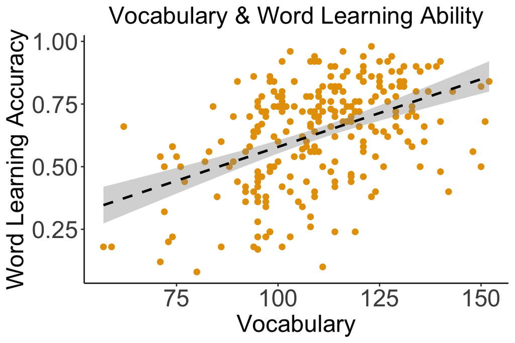

```r
#jpeg("Figs/vocab_regression_022321.jpeg")
ggplot(df, aes(x=PPVT_SS, y = WL_PC)) +
  labs(title="Vocabulary & Word Learning Ability", y = "Word Learning Accuracy", x = "Vocabulary") +
  geom_point(size=2,color='#E69F00') +
  julie.theme+
  theme(plot.title = element_text(hjust = 0.5, size =20), axis.text = element_text(size = 20), axis.title = element_text(size=20)) +
  geom_smooth(method=lm,  linetype="dashed",
             color="black")
```

```r
#dev.off()
```

### Plot comp regression

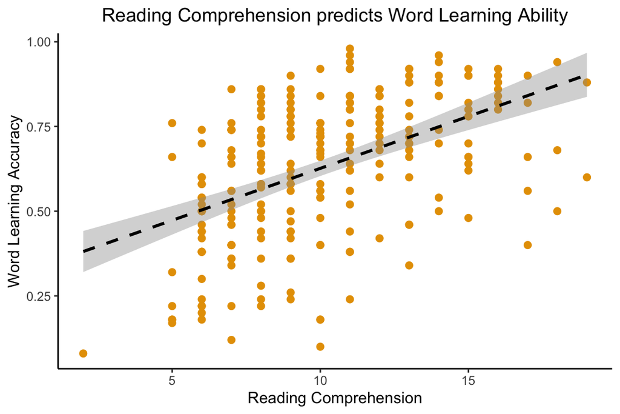

```r
#jpeg("Figs/vocab_regression.jpeg")
ggplot(df, aes(x=comp, y = WL_PC)) + labs(title="Reading Comprehension predicts Word Learning Ability", y = "Word Learning Accuracy", x = "Reading Comprehension") + geom_point(size=2,color='#E69F00') + julie.theme+ theme(plot.title = element_text(hjust = 0.5)) + geom_smooth(method=lm,  linetype="dashed",
             color="black")
```

```r
#dev.off()
```

## RQ: Of the variables known to be important to word learning, do they vary across SES or age – things known to impact word learning ability?

## Vocabulary: No.

```r
vocab_model <-lm(WL_PC ~ lang_exp + digit + NWR.PCC + comp+  Mat_ed * PPVT_SS * age_months, df_step)

summary(vocab_model)
```

```
##
## Call:
## lm(formula = WL_PC ~ lang_exp + digit + NWR.PCC + comp + Mat_ed *
##     PPVT_SS * age_months, data = df_step)
##
## Residuals:
##      Min       1Q   Median       3Q      Max
## -0.57382 -0.08967  0.01527  0.09460  0.35726
##
## Coefficients:
##                             Estimate Std. Error t value Pr(>|t|)
## (Intercept)               -1.508e+00  5.990e-01  -2.517  0.01250 *
## lang_exp                  -1.816e-02  1.894e-02  -0.958  0.33882
## digit                      2.227e-03  3.941e-03   0.565  0.57261
## NWR.PCC                    1.448e-03  9.269e-04   1.563  0.11950
## comp                       1.389e-02  4.665e-03   2.977  0.00321 **
## Mat_ed                     2.870e-01  2.176e-01   1.319  0.18833
## PPVT_SS                    1.426e-02  6.051e-03   2.357  0.01926 *
## age_months                 1.052e-02  4.285e-03   2.454  0.01485 *
## Mat_ed:PPVT_SS            -3.012e-03  2.065e-03  -1.459  0.14594
## Mat_ed:age_months         -1.756e-03  1.561e-03  -1.125  0.26191
## PPVT_SS:age_months        -6.730e-05  4.351e-05  -1.547  0.12323
## Mat_ed:PPVT_SS:age_months  1.871e-05  1.504e-05   1.244  0.21480
## ---
## Signif. codes:  0 '***' 0.001 '**' 0.01 '*' 0.05 '.' 0.1 ' ' 1
##
## Residual standard error: 0.1434 on 235 degrees of freedom
## Multiple R-squared:  0.542,  Adjusted R-squared:  0.5205
## F-statistic: 25.28 on 11 and 235 DF,  p-value: < 2.2e-16
```

```r
lm.beta(vocab_model)
```

```
##
## Call:
## lm(formula = WL_PC ~ lang_exp + digit + NWR.PCC + comp + Mat_ed *
##     PPVT_SS * age_months, data = df_step)
##
## Standardized Coefficients::
##               (Intercept)                  lang_exp
##                0.00000000               -0.04791382
##                     digit                   NWR.PCC
##                0.02846562                0.07022564
##                      comp                    Mat_ed
##                0.22126359                1.88617908
##                   PPVT_SS                age_months
##                1.20852753                1.33868974
##            Mat_ed:PPVT_SS         Mat_ed:age_months
##               -2.48829102               -1.68284774
##        PPVT_SS:age_months Mat_ed:PPVT_SS:age_months
##               -1.13048238                2.17185806
```

```r
effectsize(vocab_model)
```

| Parameter | Std_Coefficient | CI | CI_low | CI_high |
| --- | --- | --- | --- | --- |
| (Intercept) | 0.02894910 | 0.95 | -0.07361627 | 0.13151448 |
| lang_exp | -0.04791382 | 0.95 | -0.14640177 | 0.05057412 |
| digit | 0.02846562 | 0.95 | -0.07079013 | 0.12772138 |
| NWR.PCC | 0.07022564 | 0.95 | -0.01831590 | 0.15876719 |
| comp | 0.22126359 | 0.95 | 0.07485752 | 0.36766966 |
| Mat_ed | -0.01718587 | 0.95 | -0.13623311 | 0.10186137 |
| PPVT_SS | 0.33579203 | 0.95 | 0.18078020 | 0.49080387 |
| age_months | 0.48811223 | 0.95 | 0.38515149 | 0.59107296 |
| Mat_ed:PPVT_SS | -0.05052929 | 0.95 | -0.14613807 | 0.04507949 |
| Mat_ed:age_months | 0.05160021 | 0.95 | -0.05384023 | 0.15704066 |

[output cut: 2 more lines]

```r
step.model <- stepAIC(vocab_model, direction = "backward",
                      trace = FALSE)
```

```r
comp_model <-lm(WL_PC ~ lang_exp + digit + NWR.PCC + PPVT_SS +  Mat_ed * comp * age_months, df)

summary(comp_model)
```

```
##
## Call:
## lm(formula = WL_PC ~ lang_exp + digit + NWR.PCC + PPVT_SS + Mat_ed *
##     comp * age_months, data = df)
##
## Residuals:
##      Min       1Q   Median       3Q      Max
## -0.56823 -0.09689  0.01167  0.10042  0.39028
##
## Coefficients:
##                          Estimate Std. Error t value Pr(>|t|)
## (Intercept)            -1.131e+00  3.556e-01  -3.179  0.00168 **
## lang_exp               -1.905e-02  1.877e-02  -1.015  0.31133
## digit                   1.605e-03  3.909e-03   0.411  0.68165
## NWR.PCC                 1.466e-03  9.172e-04   1.599  0.11124
## PPVT_SS                 3.983e-03  9.105e-04   4.374 1.83e-05 ***
## Mat_ed                  2.809e-01  1.243e-01   2.259  0.02478 *
## comp                    8.705e-02  4.030e-02   2.160  0.03179 *
## age_months              8.024e-03  2.542e-03   3.156  0.00181 **
## Mat_ed:comp            -3.101e-02  1.297e-02  -2.391  0.01759 *
## Mat_ed:age_months      -1.841e-03  9.018e-04  -2.042  0.04228 *
## comp:age_months        -4.695e-04  2.901e-04  -1.618  0.10696
## Mat_ed:comp:age_months  2.031e-04  9.518e-05   2.134  0.03387 *
## ---
## Signif. codes:  0 '***' 0.001 '**' 0.01 '*' 0.05 '.' 0.1 ' ' 1
##
## Residual standard error: 0.1422 on 235 degrees of freedom
##   (1 observation deleted due to missingness)
## Multiple R-squared:  0.5496, Adjusted R-squared:  0.5285
## F-statistic: 26.06 on 11 and 235 DF,  p-value: < 2.2e-16
```

```r
lm.beta(comp_model)
```

```
##
## Call:
## lm(formula = WL_PC ~ lang_exp + digit + NWR.PCC + PPVT_SS + Mat_ed *
##     comp * age_months, data = df)
##
## Standardized Coefficients::
##            (Intercept)               lang_exp                  digit
##             0.00000000            -0.05026875             0.02052403
##                NWR.PCC                PPVT_SS                 Mat_ed
##             0.07109093             0.33752969             1.84610381
##                   comp             age_months            Mat_ed:comp
##             1.38672117             1.02139825            -2.83176336
##      Mat_ed:age_months        comp:age_months Mat_ed:comp:age_months
##            -1.76515674            -1.18679229             2.61750111
```

```r
effectsize(comp_model)
```

| Parameter | Std_Coefficient | CI | CI_low | CI_high |
| --- | --- | --- | --- | --- |
| (Intercept) | 0.036479507 | 0.95 | -0.063901709 | 0.13686072 |
| lang_exp | -0.050268747 | 0.95 | -0.147876766 | 0.04733927 |
| digit | 0.020524031 | 0.95 | -0.077923584 | 0.11897165 |
| NWR.PCC | 0.071090925 | 0.95 | -0.016517532 | 0.15869938 |
| PPVT_SS | 0.337529693 | 0.95 | 0.185515601 | 0.48954378 |
| Mat_ed | -0.023590006 | 0.95 | -0.139989177 | 0.09280917 |
| comp | 0.241944275 | 0.95 | 0.094554673 | 0.38933388 |
| age_months | 0.481165371 | 0.95 | 0.379349829 | 0.58298091 |
| Mat_ed:comp | -0.066411973 | 0.95 | -0.171795004 | 0.03897106 |
| Mat_ed:age_months | 0.038854359 | 0.95 | -0.061573360 | 0.13928208 |

[output cut: 2 more lines]

```r
young <- df[(df$age_year <= 9),]
midage <- df[(df$age_year > 9 & df$age_year <= 12),]
old <- df[(df$age_year >= 13),]
lowses <- df[(df$ses_group == "Low SES"),]
highses <- df[(df$ses_group == "High SES"),]

young_model <-lm(WL_PC ~   Mat_ed * comp, midage)
summary(young_model)
```

```
##
## Call:
## lm(formula = WL_PC ~ Mat_ed * comp, data = midage)
##
## Residuals:
##      Min       1Q   Median       3Q      Max
## -0.37912 -0.07047  0.01597  0.09019  0.26529
##
## Coefficients:
##              Estimate Std. Error t value Pr(>|t|)
## (Intercept)  0.047754   0.097236   0.491 0.624516
## Mat_ed       0.136198   0.035808   3.804 0.000256 ***
## comp         0.062659   0.011776   5.321 7.23e-07 ***
## Mat_ed:comp -0.013057   0.003872  -3.373 0.001091 **
## ---
## Signif. codes:  0 '***' 0.001 '**' 0.01 '*' 0.05 '.' 0.1 ' ' 1
##
## Residual standard error: 0.1274 on 92 degrees of freedom
## Multiple R-squared:  0.4636, Adjusted R-squared:  0.4461
## F-statistic: 26.51 on 3 and 92 DF,  p-value: 1.914e-12
```

```r
lm.beta(young_model)
```

```
##
## Call:
## lm(formula = WL_PC ~ Mat_ed * comp, data = midage)
##
## Standardized Coefficients::
## (Intercept)      Mat_ed        comp Mat_ed:comp
##    0.000000    1.073817    1.243881   -1.457375
```

```r
effectsize(young_model)
```

| Parameter | Std_Coefficient | CI | CI_low | CI_high |
| --- | --- | --- | --- | --- |
| (Intercept) | 0.190543394 | 0.95 | 0.002530104 | 0.3785567 |
| Mat_ed | 0.005737965 | 0.95 | -0.200908175 | 0.2123841 |
| comp | 0.622861066 | 0.95 | 0.431048161 | 0.8146740 |
| Mat_ed:comp | -0.349750200 | 0.95 | -0.555710635 | -0.1437898 |

```r
sim_slopes(comp_model, pred = comp, modx = age_months, mod2 = Mat_ed , johnson_neyman = TRUE)
```

```
## ███████████████ While Mat_ed (2nd moderator) = 1.01 (- 1 SD) ██████████████
##
## JOHNSON-NEYMAN INTERVAL
##
## When age_months is INSIDE the interval [12.27, 155.04], the slope of
## comp is p < .05.
##
## Note: The range of observed values of age_months is [96.00, 191.00]
##
## SIMPLE SLOPES ANALYSIS
##
## Slope of comp when age_months = 111.23 (- 1 SD):
##
##   Est.   S.E.   t val.      p
## ------ ------ -------- ------
##   0.03   0.01     3.16   0.00
##
## Slope of comp when age_months = 137.59 (Mean):
##
##   Est.   S.E.   t val.      p
## ------ ------ -------- ------
##   0.02   0.01     3.01   0.00
##
## Slope of comp when age_months = 163.95 (+ 1 SD):
##
##   Est.   S.E.   t val.      p
## ------ ------ -------- ------
##   0.01   0.01     1.44   0.15
##
## ████████████████ While Mat_ed (2nd moderator) = 2.37 (Mean) ███████████████
##
## JOHNSON-NEYMAN INTERVAL
##
## When age_months is INSIDE the interval [93.23, 186.59], the slope of
## comp is p < .05.
##
## Note: The range of observed values of age_months is [96.00, 191.00]
##
## SIMPLE SLOPES ANALYSIS
##
```

[output cut: 31 more lines]

```
##   Est.   S.E.   t val.      p
## ------ ------ -------- ------
##   0.00   0.01     0.56   0.57
##
## Slope of comp when age_months = 137.59 (Mean):
##
##   Est.   S.E.   t val.      p
## ------ ------ -------- ------
##   0.01   0.01     2.19   0.03
##
## Slope of comp when age_months = 163.95 (+ 1 SD):
##
##   Est.   S.E.   t val.      p
## ------ ------ -------- ------
##   0.02   0.01     2.70   0.01
```

### Plot reading interaction

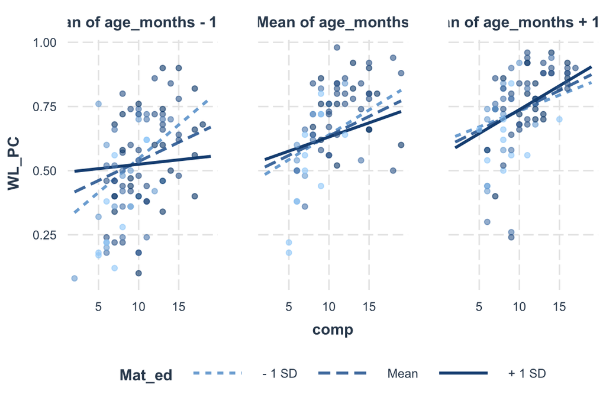

```r
interact_plot(comp_model, pred = comp, modx = Mat_ed, mod2 = age_months, plot.points = TRUE)
```

```r
df$ses_age_group<- ifelse(df$age_year <= 9 & df$Mat_ed <= 1, "Young Low SES",
                          ifelse(df$age_year > 9 & df$age_year <= 12 & df$Mat_ed <= 1, "Mid-Age Low SES",
                                 ifelse(df$age_year >= 13 & df$Mat_ed <= 1, "Older Low SES",
                                        ifelse(df$age_year <= 9 & df$Mat_ed == 2, "Young Mid SES",
                                               ifelse(df$age_year > 9 & df$age_year <= 12 & df$Mat_ed == 2, "Mid-Age Mid SES",
                                                      ifelse(df$age_year >= 13 & df$Mat_ed == 2, "Older Mid SES",
                                                             ifelse(df$age_year <= 9 & df$Mat_ed >= 3, "Young High SES",
                                                                  ifelse(df$age_year > 9 & df$age_year <= 12 & df$Mat_ed >= 3, "Mid-Age High SES",
                                                                         ifelse(df$age_year >= 13 & df$Mat_ed >= 3, "Older High SES",99)))))))))
```

```r
df$ses_age_group_2<- ifelse(df$age_year <= 9 & df$Mat_ed <= 2, "Young Low SES",
                          ifelse(df$age_year > 9 & df$age_year <= 12 & df$Mat_ed <= 2, "Mid-Age Low SES",
                                 ifelse(df$age_year >= 13 & df$Mat_ed <= 2, "Older Low SES",
                                       ifelse(df$age_year <= 9 & df$Mat_ed >= 3, "Young High SES",
                                            ifelse(df$age_year > 9 & df$age_year <= 12 & df$Mat_ed >= 3, "Mid-Age High SES",
                                                      ifelse(df$age_year >= 13 & df$Mat_ed >= 3, "Older High SES",99))))))
```

```r
df$ses_group_2 <- ifelse(df$Mat_ed <=2, "Low SES", "High SES")
```

## Group Means

```r
df %>%
  group_by(ses_age_group_2) %>%
  summarise_at(vars(WL_PC,PPVT_SS,comp), funs(mean(., na.rm=TRUE)))
```

| ses_age_group_2 | WL_PC | PPVT_SS | comp |
| --- | --- | --- | --- |
| Mid-Age High SES | 0.7340678 | 119.69492 | 11.966102 |
| Mid-Age Low SES | 0.5600000 | 97.64865 | 7.837838 |
| Older High SES | 0.7848780 | 113.34146 | 11.682927 |
| Older Low SES | 0.6948387 | 97.54839 | 8.354839 |
| Young High SES | 0.5283721 | 119.62791 | 11.093023 |
| Young Low SES | 0.4354054 | 100.43243 | 8.351351 |

## New Plotting Approach (not based on models)

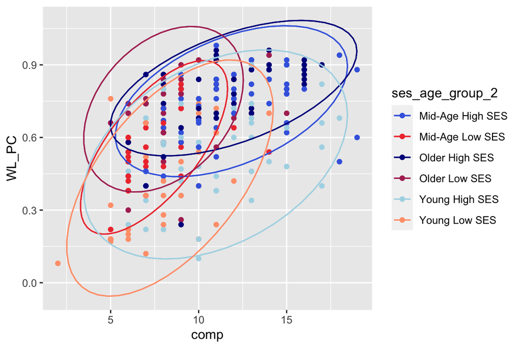

```r
# svg(filename="comp_ellipse.svg",
#     width=7,
#     height=5 ,
#     pointsize=12)

p <- ggplot(df, aes(comp,WL_PC, color = ses_age_group_2))+
  geom_point() +
  scale_color_manual(values = c("royalblue", "brown2","darkblue","maroon","lightblue", "lightsalmon")) +
  stat_ellipse()
p + stat_ellipse()
```

```r
#dev.off()
```

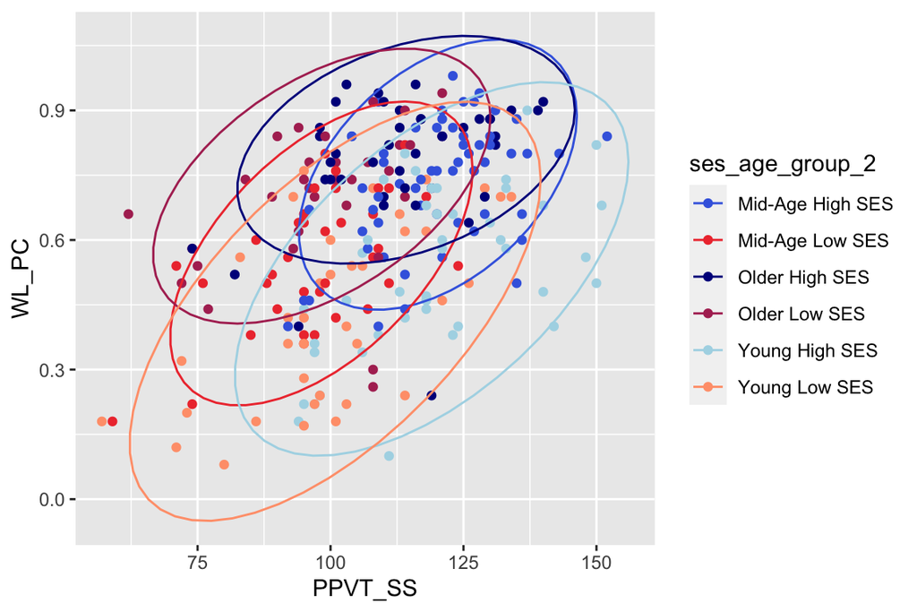

```r
# svg(filename="vocab_ellipse.svg",
#     width=7,
#     height=5 ,
#     pointsize=12)

scatterPlot <- ggplot(df,aes(PPVT_SS, WL_PC, color=ses_age_group_2)) +
  geom_point() +
  scale_color_manual(values = c("royalblue", "brown2","darkblue","maroon","lightblue", "lightsalmon")) +
  stat_ellipse()
scatterPlot
```

```r
# dev.off()
```

## New Plotting Apprach (based on models)

```r
jpeg("Figs/reading_regression_022321.jpeg")
predicted_df <- data.frame(WL_PC_pred = predict(comp_model, df), comp=df$comp, ses_age_group_2=df$ses_age_group_2)

ggplot(predicted_df, aes(comp,WL_PC_pred, color = ses_age_group_2))+
  geom_point() +
  julie.theme +
 scale_color_manual("SES x Age Group",values = c("royalblue", "brown2","darkblue","maroon","lightblue", "lightsalmon")) +
   xlab("Reading Comprehension") + ylab("Word Learning Accuracy") +stat_smooth(method=lm, se =FALSE) +theme(text = element_text(size = 15))
dev.off()
```

## New Plotting Apprach (based on models)

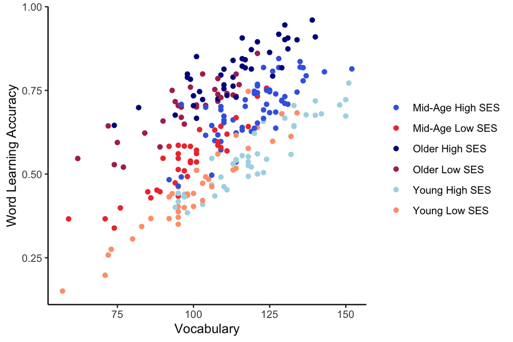

```r
predicted_df <- data.frame(WL_PC_vocab_pred = predict(vocab_model, df), vocab=df$PPVT_SS, ses_age_group_2=df$ses_age_group_2)

ggplot(predicted_df, aes(vocab,WL_PC_vocab_pred, color = ses_age_group_2))+
  geom_point() +
  julie.theme +
  scale_color_manual("SES x Age Group",values = c("royalblue", "brown2","darkblue","maroon","lightblue", "lightsalmon")) +
  xlab("Vocabulary") + ylab("Word Learning Accuracy")
```

```r
#stat_ellipse() +
```

## New Plotting Apprach (based on models)

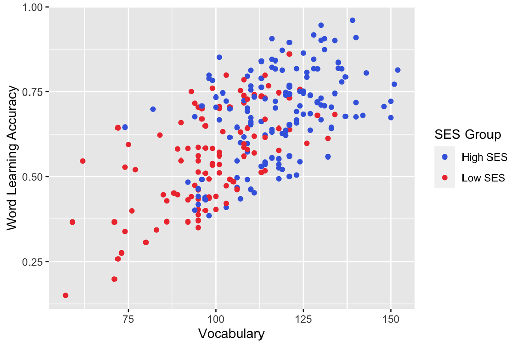

```r
predicted_df <- data.frame(WL_PC_vocab_pred = predict(vocab_model, df), vocab=df$PPVT_SS, ses_age_group_2=df$ses_group_2)

ggplot(predicted_df, aes(vocab,WL_PC_vocab_pred, color = ses_age_group_2))+
  geom_point() +
  scale_color_manual("SES Group",values = c("royalblue", "brown2")) +
  xlab("Vocabulary") + ylab("Word Learning Accuracy")
```

## Create a Table of Demographic Data sorted by Maternal Education

```r
table2 <- CreateTableOne(myvars, df, strata = c("Mat_ed"))
table2
```

```
##                         Stratified by Mat_ed
##                          0              1              2
##   n                          37             33             35
##   WL_PC (mean (SD))        0.52 (0.20)    0.57 (0.20)    0.58 (0.22)
##   PPVT_SS (mean (SD))     93.76 (16.47)  94.67 (12.88) 107.43 (11.99)
##   Mat_ed (mean (SD))       0.00 (0.00)    1.00 (0.00)    2.00 (0.00)
##   age_months (mean (SD)) 139.27 (27.16) 141.58 (26.93) 133.60 (27.53)
##   lang_exp (mean (SD))     0.97 (0.16)    0.73 (0.45)    0.37 (0.49)
##   digit (mean (SD))        8.03 (1.91)    7.12 (2.03)    8.06 (1.87)
##   comp (mean (SD))         8.16 (2.39)    7.27 (2.17)    9.03 (2.27)
##   NWR.PCC (mean (SD))      3.46 (15.71)   0.86 (0.09)    0.91 (0.07)
##                         Stratified by Mat_ed
##                          3              4              p      test
##   n                          88             55
##   WL_PC (mean (SD))        0.70 (0.19)    0.67 (0.19)  <0.001
##   PPVT_SS (mean (SD))    116.28 (13.09) 120.36 (16.11) <0.001
##   Mat_ed (mean (SD))       3.00 (0.00)    4.00 (0.00)  <0.001
##   age_months (mean (SD)) 139.09 (24.85) 134.93 (27.70)  0.642
##   lang_exp (mean (SD))     0.27 (0.52)    0.33 (0.58)  <0.001
##   digit (mean (SD))        9.03 (2.85)    8.69 (3.16)   0.005
##   comp (mean (SD))        11.43 (2.99)   11.93 (3.30)  <0.001
##   NWR.PCC (mean (SD))      2.96 (13.39)   0.92 (0.07)   0.549
```

```r
#write.table(table2, file = "demo_stats.txt", sep = ",", quote = FALSE, row.names = T)

mean(df$lang_exp)
```

```
## [1] 0.4637097
```

```r
length(which(df$lang_exp == 1))
```

```
## [1] 103
```

```r
mean(df$Ethnicity)
```

```
## [1] 0.5201613
```

```r
length(which(df$Ethnicity ==0))
```

```
## [1] 119
```

```r
t.test(df$lang_exp~df$ses_group)
```

```
##
##  Welch Two Sample t-test
##
## data:  df$lang_exp by df$ses_group
## t = -6.2792, df = 240.39, p-value = 1.578e-09
## alternative hypothesis: true difference in means is not equal to 0
## 95 percent confidence interval:
##  -0.5274988 -0.2755648
## sample estimates:
## mean in group High SES  mean in group Low SES
##              0.2937063              0.6952381
```

```r
#Number of bilingual and monolingual kids per Mat Ed group
df %>% group_by(Mat_ed,lang_exp) %>% tally()
```

| Mat_ed | lang_exp | n |
| --- | --- | --- |
| 0 | 0 | 1 |
| 0 | 1 | 36 |
| 1 | 0 | 9 |
| 1 | 1 | 24 |
| 2 | 0 | 22 |
| 2 | 1 | 13 |
| 3 | 0 | 67 |
| 3 | 1 | 18 |
| 3 | 2 | 3 |
| 4 | 0 | 40 |

[output cut: 2 more lines]

```r
#Race Breakdown
df %>% group_by(Race) %>% tally()
```

| Race | n |
| --- | --- |
| 1 | 1 |
| 2 | 18 |
| 3 | 18 |
| 4 | 172 |
| 5 | 35 |
| 6 | 1 |
| NA | 3 |